# PyLab_Complex_Numbers

```python
from __future__ import division
from sympy import *
init_printing(use_unicode=True)

from sympy.solvers import solve
from sympy import Symbol
x = Symbol('x')

import numpy as np
import cmath

# matplotlib
import matplotlib.pyplot as plt

## Text
from IPython.display import display, Markdown, Latex

import warnings
warnings.filterwarnings("ignore")
```

[Home](https://hatefdastour.github.io/) / [Linear Algebra](https://hatefdastour.github.io/notes/Linear_Algebra/)

## Python Lab

**Python Lab: Complex Numbers**

## Addition and Subtraction of Complex Numbers

For two complex numbers $z_1$ and $z_2$. $$\begin{aligned} z_1+z_2&=\left(a+b\,i\right)+\left(c+d\,i\right)=\left(a+c\right)+\left(b+d\right)\,i,\\ z_1-z_2&=\left(a+b\,i\right)-\left(c+d\,i\right)=\left(a-c\right)+\left(b-d\right)\,i.\end{aligned}$$

**Note**: In python, the imaginary part is shown with $j$

**Properties of Addition**

Let $z$, $w$, and $v$ be complex numbers.

- $z + w = w + z$.
- $(z + w) + v = z + (w + v)$.
- $z + 0 =0+z= z$.
- For every $z=a+bi$ there exists a complex number $-z = -a -bi$ such that  
  $z + (-z) =(-z)+z=0.$

**Example**:

- $(-3+6i) + (5-i) = 2+5i$.
- $(4-7i) + (6-2i) = 10-9i$.

For details please check [cmath](https://docs.python.org/3/library/cmath.html).

```python
complex(-3,6) + complex(5,-1)
```

```
(2+5j)
```

```python
complex(4,-7) + complex(6,-2)
```

```
(10-9j)
```

## Multiplication of Complex Numbers

Let $z_1=a+bi$ and $z_2=c+di$ be complex numbers. Then the **product** of $z$ and $w$ is $$ \begin{aligned} z_1z_2= (a+bi)(c+di)= (ac-bd)+ (ad+bc)i. \end{aligned}$$

**Properties of Multiplication of Complex Numbers**

Let $z, w$ and $v$ be complex numbers.

- $zw=wz$.
- $(zw)v=z(wv)$.
- $z (w+v) = zw + zv$.
- $1z=z$.
- For each $z \neq 0$, there exists $z^{-1}$ such that  
  $z z^{-1} =z^{-1}z= 1$.

**Example**: Consider $z=(-3+6i)$, $w=(5-i)$ and $v=(1-2i)$. Try the above theorem using $z_1$ and $z_2$.

```python
z = complex(-3,6)
w = complex(5,-1)
v = complex(1,-2)
```

- $zw=wz$

```python
print('zw = %s' % str(z*w))
print('wz = %s' % str(w*z))
```

```
zw = (-9+33j)
wz = (-9+33j)
```

- $((zw)v=z(wv)$

```python
print('((zw)v = %s' % str((z*w)*v))
print('z(wv) = %s' % str(z*(w*v)))
```

```
((zw)v = (57+51j)
z(wv) = (57+51j)
```

- $z (w+v) = zw + zv$

```python
print('z (w+v) = %s' % str(z*(w+v)))
print('zw + zv = %s' % str(z*w + z*v))
```

```
z (w+v) = 45j
zw + zv = 45j
```

## The Conjugate of a Complex Number

For a given complex number $z = a+b\,i$, we have $\overline{z} = a-b\,i$. $$\overline{z} = \overline{a+b\,i}=a-b\,i.$$

For example,

```python
z= 1 + 2j
display(Latex(r'$z$ = %s' % str(z)))
display(Latex(r'$\bar{z}$ = %s' % str(np.conj(z))))
```

$z$ = (1+2j)

$\bar{z}$ = (1-2j)

# Polar Form

Let $z$ be a complex number with $|z|=r$ and $\arg z=\theta$. Then $$\begin{aligned} z%=re^{i\theta} =r(\cos\theta + i\sin\theta )\end{aligned}$$ is called **a polar form** of $z$.

For example, $z = 2\,e^{i\pi/6}$

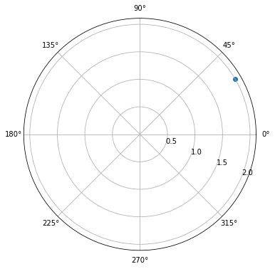

```python
fig = plt.figure(figsize=(6, 6))
ax = plt.subplot(111, projection='polar')
theta = np.pi/6
r = 2
_ = ax.scatter(theta, r)
# _ = ax.set_rmax(r+1)
_ = ax.set_rticks([0.5, 1, 1.5, 2])
_ = ax.set_rlabel_position(-22.5)
_ = ax.grid(True)
```

**Example**:

For details please check [cmath](https://docs.python.org/3/library/cmath.html).

1. In polar form

```python
z = -1/2 + np.sqrt(3)/2j
```

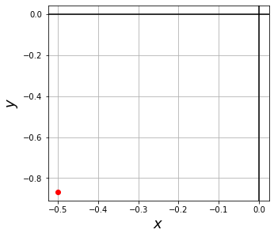

```python
fig = plt.figure(figsize=(5, 10))
ax = plt.subplot(2, 1, 1)
_ =ax.plot(z.real, z.imag, 'ro')
_ = ax.set_xlabel('$x$', fontsize=18)
_ = ax.set_ylabel('$y$', fontsize=18)
_ = ax.grid(True, which='both')
_ = ax.axhline(y=0, color='k')
_ = ax.axvline(x=0, color='k')
```

```python
cmath.polar(z)
```

$\displaystyle \left( 1.0, \ -2.0943951023932\right)$

1. In standard (Cartesian) form

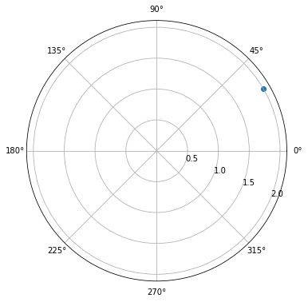

```python
fig = plt.figure(figsize=(6, 6))
ax = plt.subplot(111, projection='polar')
theta = np.pi/6
r = 2
_ = ax.scatter(theta, r)
# _ = ax.set_rmax(r+1)
_ = ax.set_rticks([0.5, 1, 1.5, 2])
_ = ax.set_rlabel_position(-22.5)
_ = ax.grid(True)
```

```python
cmath.rect(2, cmath.pi/6)
```

```
(1.7320508075688774+0.9999999999999999j)
```

# The Quadratic Formula

**Example**: Find the roots of the equation $x^2+x+1=0$.

```python
solve(x**2 + x + 1, x)
```

$\displaystyle \left[ - \frac{1}{2} - \frac{\sqrt{3} i}{2}, \ - \frac{1}{2} + \frac{\sqrt{3} i}{2}\right]$

**Example**: Find the roots of the quadratic $x^2-(3-2i)x+(5-i)=0$.

```python
solve(x**2 - (3-2j)*x + (5-1j), x)
```

$\displaystyle \left[ 1.0 + 1.0 i, \ 2.0 - 3.0 i\right]$